# Supplementary Materials

Jens Peter Andersen, Jesper Wiborg Schneider, Reshma Jagsi, Mathias Wullum Nielsen

2019-05-01

# 1 Matched papers per journal

Supplementary Figure S1 shows the percentage of papers per journal included in the analysis. The excluded papers are a combination of missing document types in Web of Science and missing name information. Journals publishing document types which are included in PubMed Medline but not Web of Science (e.g. comments, notes) can account for a large exclusion percentage for many journals. For other journals, first name information is consistently missing for some or all years. Here showing journals with > 50 papers only.

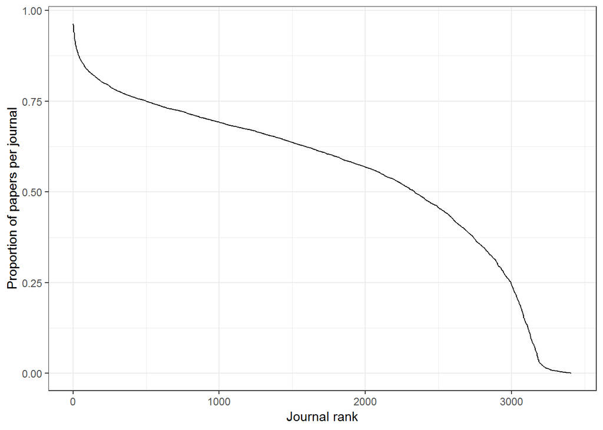

**Supplementary Figure S1.** Percentage of papers per journal included in the analysis.

# 2 Gender determination

The online tool Gender-API was used to estimate the gender of all first-name and country pairings. This pairing is important as the gender connotations for some first names vary by language and culture. As an example, the name Kim is typically male in Danish, female in English-speaking countries, and unisex in Korean. Gender-API uses co-occurrences of names and countries on social media to provide a precision score for each assignment, which we use to calculate a probability of an author being female, *f*. We exclude all authors from this analysis who only have initials registered in Web of Science, or who are from a country with unreliable gender prediction (See Supplementary Figure S2).

## 2.1 Country sampling and bias

We calculated a reliability score for each country, by determining the precision score of the Gender-API name assignment for all authors per country. Names with precision scores >= .8 are considered reliable, and the reliability for the country is the average reliability hereof. We use the reliability distribution in Supplementary Figure S2 to heuristically set a cut-off at .9 reliability for inclusion in the analysis. The excluded countries are listed in Supplementary Table S1. For some of the East-Asian countries, the explanation for the low reliability lies in the unisex-naming culture of these countries. For other countries, the probable explanation is the absence of comprehensive social media data from these countries.

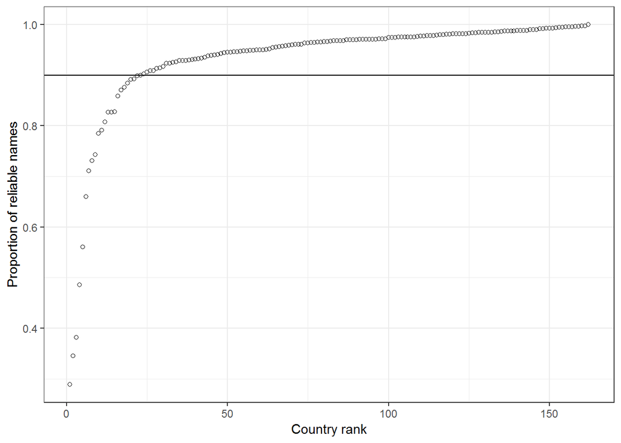

**Supplementary Figure S2.** Reliability of gender assignment per country, shown as the rank of countries.

**Supplementary Table S1.** Excluded countries due to unreliable gender assignments from first name.

| Country | Reliability |
| --- | --- |
| Taiwan | 0.29 |
| Vietnam | 0.35 |
| China | 0.38 |
| Mongolia | 0.49 |
| Myanmar [Burma] | 0.56 |
| Singapore | 0.66 |
| South Korea | 0.71 |
| Malaysia | 0.73 |
| Cambodia | 0.74 |
| Laos | 0.78 |
| Fiji | 0.79 |
| Brunei | 0.81 |
| Sri Lanka | 0.83 |
| Swaziland | 0.83 |
| Botswana | 0.83 |
| Seychelles | 0.86 |
| Zimbabwe | 0.87 |
| Nigeria | 0.88 |
| Indonesia | 0.88 |
| Burundi | 0.89 |
| Madagascar | 0.89 |
| Zambia | 0.90 |
| Guyana | 0.90 |

## 2.2 Gender representativity by year

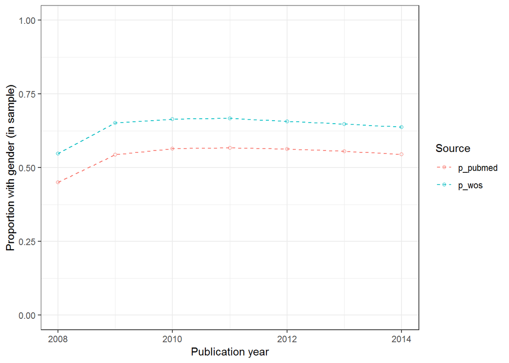

**Supplementary Figure S3.** Proportion of papers with gender assignment for all authors. Reported as function of all sampled papers (p_pubmed) and proportion of all papers matched to Web of Science (p_wos)

# 3 Specialty disambiguation

## 3.1 Specialty algorithm

To adjust for medical specialties, papers need to be classified, preferably as one specialty per paper. Such a classification is not readily available in PubMed nor Web of Science. Darmoni et al. (Darmoni et al., 2006) designed an algorithm allowing such classifications from MeSH terms assigned to papers. The algorithm operates on a MeSH-specialty assignment table (Darmoni et al., 2006; Gehanno et al., 2011) which is available through an API at http://www.hetop.eu. For each MeSH term assigned to a paper, the corresponding specialties are counted, so that the paper is classified by the most common specialty. The counts are weighted by whether the MeSH term is a major index term (full weight) or not (half weight). The list of specialties is more detailed than most other such lists, containing a total of 124 specialties. We have summarised this list into five main specialties, based on the expert field knowledge of R.J. These assignments are also available from supplementary Table S2.

## 3.2 Specialty table

**Supplementary Table S2.** List of specialty and main specialty designation, and number of papers per specialty for the full sample.

| Specialty | Main specialty | Number of papers |
| --- | --- | --- |
| environment and public health | basic science | 63147 |
| epidemiology | basic science | 58666 |
| cytology | basic science | 53840 |
| physiology | basic science | 44743 |
| virology | basic science | 34987 |
| bacteriology | basic science | 32552 |
| information science | basic science | 13815 |
| nutrition | basic science | 6058 |
| mycology | basic science | 4488 |
| toxicology | basic science | 4326 |
| equipment and supplies | basic science | 4209 |
| parasitology | basic science | 3700 |
| pharmacy | basic science | 3334 |
| economics | basic science | 3249 |
| education | basic science | 2437 |
| histology | basic science | 1867 |
| environnement | basic science | 1599 |
| organization and administration | basic science | 1261 |
| evidence-based medicine | basic science | 891 |
| statistics | basic science | 861 |
| research | basic science | 845 |
| phytotherapy | basic science | 655 |
| embryology | basic science | 618 |
| microbiology | basic science | 584 |
| history of medicine | basic science | 411 |
| law | basic science | 270 |
| medical informatics | basic science | 265 |
| disease transmission | basic science | 224 |
| social affairs | basic science | 195 |
| pharmacology | basic science | 162 |

[output cut: 91 more lines]

# 4 Geographical regions

## 4.1 Attention

The attached table is long. To view it, click the tab above.

## 4.2 Table of geographical regions

**Supplementary Table S3.** Groupings of countries by geographical region.

| Country | area_code |
| --- | --- |
| Algeria | arab |
| Egypt | arab |
| Jordan | arab |
| Kuwait | arab |
| Lebanon | arab |
| Morocco | arab |
| Oman | arab |
| Qatar | arab |
| Saudi Arabia | arab |
| Syria | arab |
| Tunisia | arab |
| United Arab Emirates | arab |
| Georgia | commonwealth_is |
| Kazakhstan | commonwealth_is |
| Kyrgyzstan | commonwealth_is |
| Russia | commonwealth_is |
| Tajikistan | commonwealth_is |
| Uzbekistan | commonwealth_is |
| Brunei | e_asia |
| Cambodia | e_asia |
| China | e_asia |
| Indonesia | e_asia |
| Japan | e_asia |
| Malaysia | e_asia |
| Mongolia | e_asia |
| Myanmar [Burma] | e_asia |
| Philippines | e_asia |
| Singapore | e_asia |
| South Korea | e_asia |
| Taiwan | e_asia |

[output cut: 108 more lines]

# 5 Regression results

## 5.1 Tweedie regression results

**Supplementary Table S4.** Tweedie regression results

| Outcome | Model | Predictor | Raw parameters Estimate | Raw parameters Std. Error | Raw parameters EE | Raw parameters EE.LCL | Raw parameters EE.UCL | Standardized parameters Estimate | Standardized parameters Std. Error | Standardized parameters EE | Standardized parameters EE.LCL | Standardized parameters EE.UCL |
| --- | --- | --- | --- | --- | --- | --- | --- | --- | --- | --- | --- | --- |
| NCS | Sample 1 | (Intercept) | -0.39 | 0.0020 | 0.68 | 0.68 | 0.68 | 0.03 | 0.0010 | 1.03 | 1.03 | 1.03 |
| NCS | Sample 1 | case | -0.02 | 0.0020 | 0.98 | 0.98 | 0.98 | -0.02 | 0.0020 | 0.98 | 0.98 | 0.98 |
| NCS | Sample 1 | n_authors | -0.01 | 0.0002 | 0.99 | 0.99 | 0.99 | -0.06 | 0.0018 | 0.94 | 0.94 | 0.94 |
| NCS | Sample 1 | int_collab | 0.11 | 0.0024 | 1.12 | 1.11 | 1.12 | 0.11 | 0.0024 | 1.12 | 1.11 | 1.12 |
| NCS | Sample 1 | selfcit | 0.07 | 0.0001 | 1.07 | 1.07 | 1.07 | 0.51 | 0.0009 | 1.66 | 1.65 | 1.66 |
| NCS | Sample 1 | mncs_journal | 0.26 | 0.0006 | 1.29 | 1.29 | 1.29 | 0.50 | 0.0013 | 1.65 | 1.64 | 1.65 |
| NCS | Sample 2 | (Intercept) | -0.46 | 0.0025 | 0.63 | 0.63 | 0.64 | 0.01 | 0.0012 | 1.01 | 1.01 | 1.01 |
| NCS | Sample 2 | case | -0.01 | 0.0025 | 0.99 | 0.98 | 0.99 | -0.01 | 0.0025 | 0.99 | 0.98 | 0.99 |
| NCS | Sample 2 | n_authors | 0.00 | 0.0003 | 1.00 | 1.00 | 1.00 | -0.03 | 0.0023 | 0.97 | 0.97 | 0.98 |
| NCS | Sample 2 | int_collab | 0.10 | 0.0031 | 1.11 | 1.10 | 1.11 | 0.10 | 0.0031 | 1.11 | 1.10 | 1.11 |
| NCS | Sample 2 | selfcit | 0.07 | 0.0001 | 1.07 | 1.07 | 1.07 | 0.46 | 0.0008 | 1.58 | 1.58 | 1.59 |
| NCS | Sample 2 | mncs_journal | 0.30 | 0.0009 | 1.35 | 1.34 | 1.35 | 0.57 | 0.0016 | 1.76 | 1.75 | 1.77 |
| NCS | Sample 3 | (Intercept) | -0.36 | 0.0033 | 0.70 | 0.69 | 0.70 | 0.03 | 0.0016 | 1.03 | 1.02 | 1.03 |
| NCS | Sample 3 | case | -0.04 | 0.0033 | 0.96 | 0.96 | 0.97 | -0.04 | 0.0033 | 0.96 | 0.96 | 0.97 |
| NCS | Sample 3 | n_authors | 0.00 | 0.0004 | 1.00 | 0.99 | 1.00 | -0.04 | 0.0029 | 0.97 | 0.96 | 0.97 |
| NCS | Sample 3 | int_collab | 0.13 | 0.0039 | 1.14 | 1.13 | 1.15 | 0.13 | 0.0039 | 1.14 | 1.13 | 1.15 |
| NCS | Sample 3 | selfcit | 0.05 | 0.0001 | 1.05 | 1.05 | 1.05 | 0.36 | 0.0010 | 1.43 | 1.42 | 1.43 |
| NCS | Sample 3 | mncs_journal | 0.26 | 0.0010 | 1.30 | 1.29 | 1.30 | 0.49 | 0.0019 | 1.63 | 1.62 | 1.64 |

Note:  
EE : Exponentiated estimate  
EE.LCL : Lower confidence limit of exponentiated estimate  
EE.UCL : Upper confidence limit of exponentiated estimate

## 5.2 Tweedie regression on unmatched data

**Supplementary Table S5.** Regression results for Tweedie regressions on the full, unmatched sample, using NCS as outcome.

| Outcome | Model | Predictor | Estimate | Std. Error | EE | EE.LCL | EE.UCL |
| --- | --- | --- | --- | --- | --- | --- | --- |
| NCS | F_First | (Intercept) | 0.00 | 0.0013 | 1.00 | 1.00 | 1.01 |
| NCS | F_First | f_first | -0.01 | 0.0018 | 0.99 | 0.98 | 0.99 |
| NCS | F_First | n_authors | -0.02 | 0.0016 | 0.98 | 0.98 | 0.98 |
| NCS | F_First | int_collab | 0.12 | 0.0022 | 1.13 | 1.13 | 1.14 |
| NCS | F_First | selfcit | 0.42 | 0.0005 | 1.52 | 1.51 | 1.52 |
| NCS | F_First | mncs_journal | 0.54 | 0.0011 | 1.71 | 1.71 | 1.72 |
| NCS | F_Last | (Intercept) | 0.00 | 0.0012 | 1.00 | 1.00 | 1.00 |
| NCS | F_Last | f_last | -0.01 | 0.0020 | 0.99 | 0.99 | 1.00 |
| NCS | F_Last | n_authors | -0.02 | 0.0016 | 0.98 | 0.98 | 0.98 |
| NCS | F_Last | int_collab | 0.12 | 0.0022 | 1.13 | 1.13 | 1.14 |
| NCS | F_Last | selfcit | 0.42 | 0.0005 | 1.52 | 1.51 | 1.52 |
| NCS | F_Last | mncs_journal | 0.54 | 0.0011 | 1.71 | 1.71 | 1.72 |
| NCS | F_Both | (Intercept) | 0.00 | 0.0011 | 1.00 | 1.00 | 1.00 |
| NCS | F_Both | f_both | -0.02 | 0.0025 | 0.98 | 0.97 | 0.98 |
| NCS | F_Both | n_authors | -0.02 | 0.0016 | 0.98 | 0.98 | 0.98 |
| NCS | F_Both | int_collab | 0.12 | 0.0022 | 1.13 | 1.13 | 1.14 |
| NCS | F_Both | selfcit | 0.42 | 0.0005 | 1.52 | 1.51 | 1.52 |
| NCS | F_Both | mncs_journal | 0.54 | 0.0011 | 1.71 | 1.71 | 1.72 |

Note:  
EE : Exponentiated estimate  
EE.LCL : Lower confidence limit of exponentiated estimate  
EE.UCL : Upper confidence limit of exponentiated estimate

## 5.3 Tweedie regression on MNCS Journal quantiles

**Supplementary Table S6.** Tweedie regression of standardized parameters, using MNCS Journal quantiles rather than measurements.

| Outcome | Model | Predictor | Estimate | Std. Error | EE | EE.LCL | EE.UCL |
| --- | --- | --- | --- | --- | --- | --- | --- |
| NCS | Sample 1 | (Intercept) | -0.32 | 0.0019 | 0.73 | 0.72 | 0.73 |
| NCS | Sample 1 | case | -0.02 | 0.0020 | 0.98 | 0.98 | 0.99 |
| NCS | Sample 1 | n_authors | -0.07 | 0.0019 | 0.93 | 0.93 | 0.93 |
| NCS | Sample 1 | int_collab | 0.08 | 0.0025 | 1.08 | 1.08 | 1.09 |
| NCS | Sample 1 | selfcit | 0.54 | 0.0009 | 1.71 | 1.71 | 1.72 |
| NCS | Sample 1 | mncs_j_high | 1.19 | 0.0039 | 3.28 | 3.25 | 3.30 |
| NCS | Sample 1 | mncs_j_med | 0.56 | 0.0021 | 1.75 | 1.74 | 1.75 |
| NCS | Sample 2 | (Intercept) | -0.34 | 0.0024 | 0.71 | 0.71 | 0.72 |
| NCS | Sample 2 | case | -0.01 | 0.0026 | 0.99 | 0.99 | 1.00 |
| NCS | Sample 2 | n_authors | -0.03 | 0.0024 | 0.97 | 0.96 | 0.97 |
| NCS | Sample 2 | int_collab | 0.08 | 0.0032 | 1.08 | 1.08 | 1.09 |
| NCS | Sample 2 | selfcit | 0.47 | 0.0008 | 1.61 | 1.60 | 1.61 |
| NCS | Sample 2 | mncs_j_high | 1.23 | 0.0051 | 3.41 | 3.37 | 3.44 |
| NCS | Sample 2 | mncs_j_med | 0.57 | 0.0027 | 1.76 | 1.75 | 1.77 |
| NCS | Sample 3 | (Intercept) | -0.34 | 0.0033 | 0.72 | 0.71 | 0.72 |
| NCS | Sample 3 | case | -0.03 | 0.0035 | 0.97 | 0.96 | 0.98 |
| NCS | Sample 3 | n_authors | -0.06 | 0.0032 | 0.94 | 0.93 | 0.95 |
| NCS | Sample 3 | int_collab | 0.09 | 0.0042 | 1.09 | 1.08 | 1.10 |
| NCS | Sample 3 | selfcit | 0.40 | 0.0011 | 1.50 | 1.49 | 1.50 |
| NCS | Sample 3 | mncs_j_high | 1.26 | 0.0065 | 3.53 | 3.48 | 3.57 |
| NCS | Sample 3 | mncs_j_med | 0.58 | 0.0037 | 1.78 | 1.77 | 1.79 |

Note:  
EE : Exponentiated estimate  
EE.LCL : Lower confidence limit of exponentiated estimate  
EE.UCL : Upper confidence limit of exponentiated estimate  
mncs_j_high : MNCS Journal scores in and above the 95th percentile  
mncs_j_med: MNCS Journal scores from the 50th to the 94th percentile

## 5.4 Logistic regression

**Supplementary Table S7.** Logistic regression results

| Outcome | Model | Predictor | Raw parameters Estimate | Raw parameters Std. Error | Raw parameters OR | Raw parameters OR.LCL | Raw parameters OR.UCL | Standardized parameters Estimate | Standardized parameters Std. Error | Standardized parameters OR | Standardized parameters OR.LCL | Standardized parameters OR.UCL |
| --- | --- | --- | --- | --- | --- | --- | --- | --- | --- | --- | --- | --- |
| case | Sample 1 | (Intercept) | 0.00 | 0.0041 | 1.00 | 0.99 | 1.01 | 0.00 | 0.0020 | 1.00 | 1.00 | 1.00 |
| case | Sample 1 | n_authors | 0.02 | 0.0006 | 1.02 | 1.01 | 1.02 | 0.12 | 0.0044 | 1.13 | 1.12 | 1.14 |
| case | Sample 1 | int_collab | -0.03 | 0.0051 | 0.97 | 0.96 | 0.98 | -0.03 | 0.0051 | 0.97 | 0.96 | 0.98 |
| case | Sample 1 | selfcit | -0.02 | 0.0007 | 0.98 | 0.98 | 0.98 | -0.15 | 0.0047 | 0.86 | 0.86 | 0.87 |
| case | Sample 1 | mncs_journal | -0.03 | 0.0023 | 0.97 | 0.96 | 0.97 | -0.07 | 0.0044 | 0.94 | 0.93 | 0.94 |
| case | Sample 2 | (Intercept) | 0.12 | 0.0051 | 1.13 | 1.12 | 1.14 | 0.00 | 0.0025 | 1.00 | 0.99 | 1.00 |
| case | Sample 2 | n_authors | -0.01 | 0.0007 | 0.99 | 0.99 | 0.99 | -0.08 | 0.0055 | 0.93 | 0.92 | 0.94 |
| case | Sample 2 | int_collab | -0.01 | 0.0064 | 0.99 | 0.98 | 1.01 | -0.01 | 0.0064 | 0.99 | 0.98 | 1.01 |
| case | Sample 2 | selfcit | -0.01 | 0.0008 | 0.99 | 0.98 | 0.99 | -0.10 | 0.0059 | 0.91 | 0.90 | 0.92 |
| case | Sample 2 | mncs_journal | -0.03 | 0.0029 | 0.97 | 0.96 | 0.98 | -0.06 | 0.0055 | 0.94 | 0.93 | 0.95 |
| case | Sample 3 | (Intercept) | 0.14 | 0.0069 | 1.15 | 1.13 | 1.16 | 0.00 | 0.0033 | 1.00 | 0.99 | 1.01 |
| case | Sample 3 | n_authors | 0.00 | 0.0009 | 1.00 | 1.00 | 1.00 | -0.02 | 0.0073 | 0.98 | 0.97 | 1.00 |
| case | Sample 3 | int_collab | 0.01 | 0.0083 | 1.01 | 0.99 | 1.03 | 0.01 | 0.0083 | 1.01 | 0.99 | 1.03 |
| case | Sample 3 | selfcit | -0.03 | 0.0012 | 0.97 | 0.97 | 0.97 | -0.21 | 0.0082 | 0.81 | 0.80 | 0.82 |
| case | Sample 3 | mncs_journal | -0.06 | 0.0040 | 0.94 | 0.94 | 0.95 | -0.11 | 0.0076 | 0.90 | 0.88 | 0.91 |

Note:  
OR : Odds ratios  
OR.LCL : Lower confidence limit of odds ratios  
OR.UCL : Upper confidence limit of odds ratios

## 5.5 Negative binomial regression results

**Supplementary Table S8.** Regression results for the three negative binomial regressions with times cited (CS) as outcome.

| Outcome | Model | Predictor | Estimate | Std. Error | IRR | IRR.LCL | IRR.UCL |
| --- | --- | --- | --- | --- | --- | --- | --- |
| CS | Sample 1 | (Intercept) | 1.44 | 0.0019 | 4.22 | 4.21 | 4.24 |
| CS | Sample 1 | case | 0.00 | 0.0017 | 1.00 | 0.99 | 1.00 |
| CS | Sample 1 | n_authors | 0.00 | 0.0002 | 1.00 | 1.00 | 1.00 |
| CS | Sample 1 | int_collab | 0.04 | 0.0021 | 1.04 | 1.04 | 1.05 |
| CS | Sample 1 | selfcit | 0.14 | 0.0002 | 1.15 | 1.15 | 1.15 |
| CS | Sample 1 | mncs_journal | 0.43 | 0.0009 | 1.53 | 1.53 | 1.54 |
| CS | Sample 2 | (Intercept) | 1.42 | 0.0024 | 4.13 | 4.11 | 4.15 |
| CS | Sample 2 | case | -0.01 | 0.0021 | 0.99 | 0.98 | 0.99 |
| CS | Sample 2 | n_authors | 0.00 | 0.0003 | 1.00 | 1.00 | 1.00 |
| CS | Sample 2 | int_collab | 0.04 | 0.0027 | 1.05 | 1.04 | 1.05 |
| CS | Sample 2 | selfcit | 0.14 | 0.0003 | 1.15 | 1.15 | 1.15 |
| CS | Sample 2 | mncs_journal | 0.44 | 0.0011 | 1.55 | 1.55 | 1.56 |
| CS | Sample 3 | (Intercept) | 1.41 | 0.0032 | 4.11 | 4.08 | 4.14 |
| CS | Sample 3 | case | -0.01 | 0.0028 | 0.99 | 0.98 | 0.99 |
| CS | Sample 3 | n_authors | 0.00 | 0.0004 | 1.00 | 1.00 | 1.00 |
| CS | Sample 3 | int_collab | 0.04 | 0.0035 | 1.04 | 1.03 | 1.05 |
| CS | Sample 3 | selfcit | 0.14 | 0.0004 | 1.15 | 1.15 | 1.15 |
| CS | Sample 3 | mncs_journal | 0.44 | 0.0015 | 1.55 | 1.55 | 1.56 |

Note:  
IRR : Incidence rate ratios  
IRR.LCL : Lower confidence limit of incidence rate ratios  
IRR.UCL : Upper confidence limit of incidence rate ratios

## 5.6 Model fit

**Supplementary Table S9.** Dispersion parameters for all regressions.

| Regression model | Sample 1 | Sample 2 | Sample 3 |
| --- | --- | --- | --- |
| Tweedie regression, raw params | 1.002 | 1.010 | 1.003 |
| Tweedie regression, unmatched data | 1.027 | 1.028 | 1.027 |
| Tweedie regression, MNCS Journal quantiles | 1.058 | 1.098 | 1.137 |
| Logistic regression, raw params | 1.000 | 1.000 | 1.000 |
| Negative binomial regression | 1.000 | 1.000 | 1.000 |

# 6 Literature review

[output not shown]

## 6.1 Search strategy

Databases: PubMed and Google Scholar

Years: 2006 through 2016.

Search terms (all fields):

[output not shown]

Inclusion criteria: +Quantitative study, + numerical specifications on gender analysis of scientific performance, citation-related indices

# References

Böhm M, Papoutsis K, Gottwik M, Ukena C. 2015. Publication performance of women compared to men in German cardiology. *International Journal of Cardiology* **181**:267–269. doi:10.1016/j.ijcard.2014.12.018

Choi M, Fuller CD, Thomas CR. 2009. Estimation of Citation-Based Scholarly Activity Among Radiation Oncology Faculty at Domestic Residency-Training Institutions: 1996-2007. *International Journal of Radiation Oncology Biology Physics* **74**:172–178. doi:10.1016/j.ijrobp.2008.07.030

Darmoni SJ, Névéol A, Renard J-M, Gehanno J-F, Soualmia LF, Dahamna B, Thirion B. 2006. A MEDLINE categorization algorithm. *BMC Medical Informatics and Decision Making* **6**:7–7. doi:10.1186/1472-6947-6-7

Eloy JA, Svider PF, Cherla DV, Diaz L, Kovalerchik O, Mauro KM, Baredes S, Chandrasekhar SS. 2013. Gender disparities in research productivity among 9952 academic physicians. *Laryngoscope* **123**:1865–1875. doi:10.1002/lary.24039

Frandsen TF, Jacobsen RH, Wallin JA, Brixen K, Ousager J. 2015. Gender differences in scientific performance: A bibliometric matching analysis of Danish health sciences graduates. *Journal of Informetrics* **9**:1007–1017. doi:10.1016/j.joi.2015.09.006

Gehanno J-F, Ladner J, Rollin L, Dahamna B, Darmoni SJ. 2011. How are the different specialties represented in the major journals in general medicine? *BMC Medical Informatics and Decision Making* **11**. doi:10.1186/1472-6947-11-3

Holliday EB, Jagsi R, Wilson LD, Choi M, Thomas CR, Fuller CD. 2014. Gender Differences in Publication Productivity, Academic Position, Career Duration, and Funding Among U.S. Academic Radiation Oncology Faculty. *Academic Medicine* **89**:767–773. doi:10.1097/ACM.0000000000000229

Housri N, Cheung MC, Koniaris LG, Zimmers TA. 2008. Scientific Impact of Women in Academic Surgery. *Journal of Surgical Research* **148**:13–16. doi:10.1016/j.jss.2008.02.015

Ingram DG. 2015. Publication Measures of Scholarly Productivity: Norms for Academic Pediatric Pulmonologists. *Pediatric Allergy, Immunology, and Pulmonology* **28**:183–186. doi:10.1089/ped.2015.0511

Klimo PJ, Venable GT, Khan NR, Taylor DR, Shepherd BA, Thompson CJ, Selden NR. 2014. Bibliometric evaluation of pediatric neurosurgery in North America. *Journal of neurosurgery Pediatrics* **14**:695–703. doi:10.3171/2014.8.PEDS1488

Larivière V, Vignola-Gagné E, Villeneuve C, Gélinas P, Gingras Y. 2011. Sex differences in research funding, productivity and impact: an analysis of Québec university professors. *Scientometrics* **87**:483–498. doi:10.1007/s11192-011-0369-y

Martinez M, Lopez S, Beebe K. 2015. Gender Comparison of Scholarly Production in the Musculoskeletal Tumor Society Using the Hirsch Index. *Journal of Surgical Education* **72**:1172–1178. doi:10.1016/j.jsurg.2015.06.020

Mirnezami SR, Beaudry C, Larivière V. 2016. What determines researchers’ scientific impact? A case study of Quebec researchers. *Science and Public Policy* **43**:262–274. doi:10.1093/scipol/scv038

Mueller CM, Gaudilliere DK, Kin C, Menorca R, Girod S. 2016. Gender disparities in scholarly productivity of US academic surgeons. *Journal of Surgical Research* **203**:28–33. doi:10.1016/j.jss.2016.03.060

Nielsen MW. 2016. Gender inequality and research performance: moving beyond individual-meritocratic explanations of academic advancement. *Studies in Higher Education* **41**:2044–2060. doi:10.1080/03075079.2015.1007945

Okhovati M, Bazrafshan A, Zare M, Moradzade M, Mokhtari AM. 2015. Research Performance Measures and the Moderating Role of Faculty Characteristics in Epidemiology. *Global Journal of Health Science* **8**:72. doi:10.5539/gjhs.v8n5p72

Pagel PS, Hudetz JA. 2015. Scholarly Productivity and National Institutes of Health Funding of Foundation for Anesthesia Education and Research Grant Recipients: Insights from a bibliometric analysis. *Anesthesiology* **123**:683–691.

Pagel PS, Hudetz JA. 2011. An analysis of scholarly productivity in United States academic anaesthesiologists by citation bibliometrics. *Anaesthesia* **66**:873–878. doi:10.1111/j.1365-2044.2011.06860.x

Paik AM, Mady LJ, Villanueva NL, Goljo E, Svider PF, Ciminello F, Eloy JA. 2014. Research productivity and gender disparities: A look at academic plastic surgery. *Journal of Surgical Education* **71**:593–600. doi:10.1016/j.jsurg.2014.01.010

Pashkova AA, Svider PF, Chang CY, Diaz L, Eloy JA, Eloy JD. 2013. Gender disparity among US anaesthesiologists: Are women underrepresented in academic ranks and scholarly productivity? *Acta Anaesthesiologica Scandinavica* **57**:1058–1064. doi:10.1111/aas.12141

Raj A, Carr PL, Kaplan SE, Terrin N, Breeze JL, Freund KM. 2016. Longitudinal analysis of gender differences in academic productivity among medical faculty across 24 medical schools in the United States. *Academic Medicine* **91**:1074–1079. doi:10.1097/ACM.0000000000001251

Rana S, Holliday EB, Jagsi R, Wilson LD, Choi M, Thomas CR, Fuller CD. 2013. Scholastic activity among radiation oncology residents at us academic institutions: A benchmark analysis. *Journal of Cancer Education* **28**:541–546. doi:10.1007/s13187-013-0500-2

Susarla SM, Swanson EW, Lopez J, Peacock ZS, Dodson TB. 2015. Does self-citation influence quantitative measures of research productivity among academic oral and maxillofacial surgeons? *Journal of Oral and Maxillofacial Surgery* **73**:1981e1–1981e7. doi:10.1016/j.joms.2015.05.018

Winnik S, Raptis DA, Walker JH, Hasun M, Speer T, Clavien PA, Komajda M, Bax JJ, Tendera M, Fox K, Van De Werf F, Mundow C, Lüscher TF, Ruschitzka F, Matter CM. 2012. From abstract to impact in cardiovascular research: Factors predicting publication and citation. *European Heart Journal* **33**:3034–3045. doi:10.1093/eurheartj/ehs113